# Correlation and Regression key

John Shorter

Mar/13/2024

# Load package

```r
library(ggplot2)
library(tidyr)
library(dplyr)
library(readr)
library(readxl)
library(RColorBrewer)
library(viridis)
child_mortality <- read_csv("/work/Data/Rmodule_data/child_mortality_0_5_year_olds_dying_per_1000_born.csv", col_types = cols())
babies_per_woman <- read_csv("/work/Data/Rmodule_data/children_per_woman_total_fertility.csv", col_types = cols())
income <- read_csv("/work/Data/Rmodule_data/income_per_person_gdppercapita_ppp_inflation_adjusted.csv", col_types = cols())
```

The goal is to remind us not only the “gaps” between developed and developing worlds, but also the amazing continuous improvements of quality of life through time.

1. Child mortality (0 - 5 year old) dying per 1000 born.
2. Median income per person.
3. Births per woman.

These were recorded from year 1800 and projected all the way to 2100.

```r
head(child_mortality)
```

```
## # A tibble: 6 × 302
##   country  `1800` `1801` `1802` `1803` `1804` `1805` `1806` `1807` `1808` `1809`
##   <chr>     <dbl>  <dbl>  <dbl>  <dbl>  <dbl>  <dbl>  <dbl>  <dbl>  <dbl>  <dbl>
## 1 Afghani…    469    469    469    469    469    469    470    470    470    470
## 2 Albania     375    375    375    375    375    375    375    375    375    375
## 3 Algeria     460    460    460    460    460    460    460    460    460    460
## 4 Andorra      NA     NA     NA     NA     NA     NA     NA     NA     NA     NA
## 5 Angola      486    486    486    486    486    486    486    486    486    486
## 6 Antigua…    474    470    466    462    458    455    451    447    444    440
## # ℹ 291 more variables: `1810` <dbl>, `1811` <dbl>, `1812` <dbl>, `1813` <dbl>,
## #   `1814` <dbl>, `1815` <dbl>, `1816` <dbl>, `1817` <dbl>, `1818` <dbl>,
## #   `1819` <dbl>, `1820` <dbl>, `1821` <dbl>, `1822` <dbl>, `1823` <dbl>,
## #   `1824` <dbl>, `1825` <dbl>, `1826` <dbl>, `1827` <dbl>, `1828` <dbl>,
## #   `1829` <dbl>, `1830` <dbl>, `1831` <dbl>, `1832` <dbl>, `1833` <dbl>,
## #   `1834` <dbl>, `1835` <dbl>, `1836` <dbl>, `1837` <dbl>, `1838` <dbl>,
## #   `1839` <dbl>, `1840` <dbl>, `1841` <dbl>, `1842` <dbl>, `1843` <dbl>, …
```

```r
head(income)
```

```
## # A tibble: 6 × 242
##   country  `1800` `1801` `1802` `1803` `1804` `1805` `1806` `1807` `1808` `1809`
##   <chr>     <dbl>  <dbl>  <dbl>  <dbl>  <dbl>  <dbl>  <dbl>  <dbl>  <dbl>  <dbl>
## 1 Afghani…    603    603    603    603    603    603    603    603    603    603
## 2 Albania     667    667    667    667    667    668    668    668    668    668
## 3 Algeria     715    716    717    718    719    720    721    722    723    724
## 4 Andorra    1200   1200   1200   1200   1210   1210   1210   1210   1220   1220
## 5 Angola      618    620    623    626    628    631    634    637    640    642
## 6 Antigua…    757    757    757    757    757    757    757    758    758    758
## # ℹ 231 more variables: `1810` <dbl>, `1811` <dbl>, `1812` <dbl>, `1813` <dbl>,
## #   `1814` <dbl>, `1815` <dbl>, `1816` <dbl>, `1817` <dbl>, `1818` <dbl>,
## #   `1819` <dbl>, `1820` <dbl>, `1821` <dbl>, `1822` <dbl>, `1823` <dbl>,
## #   `1824` <dbl>, `1825` <dbl>, `1826` <dbl>, `1827` <dbl>, `1828` <dbl>,
## #   `1829` <dbl>, `1830` <dbl>, `1831` <dbl>, `1832` <dbl>, `1833` <dbl>,
## #   `1834` <dbl>, `1835` <dbl>, `1836` <dbl>, `1837` <dbl>, `1838` <dbl>,
## #   `1839` <dbl>, `1840` <dbl>, `1841` <dbl>, `1842` <dbl>, `1843` <dbl>, …
```

```r
head(babies_per_woman)
```

```
## # A tibble: 6 × 302
##   country  `1800` `1801` `1802` `1803` `1804` `1805` `1806` `1807` `1808` `1809`
##   <chr>     <dbl>  <dbl>  <dbl>  <dbl>  <dbl>  <dbl>  <dbl>  <dbl>  <dbl>  <dbl>
## 1 Afghani…   7      7      7      7      7      7      7      7      7      7
## 2 Albania    4.6    4.6    4.6    4.6    4.6    4.6    4.6    4.6    4.6    4.6
## 3 Algeria    6.99   6.99   6.99   6.99   6.99   6.99   6.99   6.99   6.99   6.99
## 4 Angola     6.93   6.93   6.93   6.93   6.93   6.93   6.93   6.94   6.94   6.94
## 5 Antigua…   5      5      4.99   4.99   4.99   4.98   4.98   4.97   4.97   4.97
## 6 Argenti…   6.8    6.8    6.8    6.8    6.8    6.8    6.8    6.8    6.8    6.8
## # ℹ 291 more variables: `1810` <dbl>, `1811` <dbl>, `1812` <dbl>, `1813` <dbl>,
## #   `1814` <dbl>, `1815` <dbl>, `1816` <dbl>, `1817` <dbl>, `1818` <dbl>,
## #   `1819` <dbl>, `1820` <dbl>, `1821` <dbl>, `1822` <dbl>, `1823` <dbl>,
## #   `1824` <dbl>, `1825` <dbl>, `1826` <dbl>, `1827` <dbl>, `1828` <dbl>,
## #   `1829` <dbl>, `1830` <dbl>, `1831` <dbl>, `1832` <dbl>, `1833` <dbl>,
## #   `1834` <dbl>, `1835` <dbl>, `1836` <dbl>, `1837` <dbl>, `1838` <dbl>,
## #   `1839` <dbl>, `1840` <dbl>, `1841` <dbl>, `1842` <dbl>, `1843` <dbl>, …
```

These tables are not in tidy format. The years spread out across 200+ columns. Let’s make them into the tidy format first, and then we’ll join them by matching the country and year columns.

```r
child_mortality_tidy <- child_mortality %>%
  pivot_longer(names_to = "year", values_to = "death_per_1000", cols = c(2:302))

income_tidy <- income %>%
  pivot_longer(names_to = "year", values_to = "income", cols = c(2:242))

babies_per_woman_tidy <- babies_per_woman %>%
  pivot_longer(names_to = "year", values_to = "birth", cols = c(2:302))

mortality_and_income_and_birth <- child_mortality_tidy %>%
  inner_join(income_tidy, by = c("country", "year")) %>%
  inner_join(babies_per_woman_tidy, by = c("country","year")) %>%
  mutate(log10_income = log10(income))

head(mortality_and_income_and_birth)
```

```
## # A tibble: 6 × 6
##   country     year  death_per_1000 income birth log10_income
##   <chr>       <chr>          <dbl>  <dbl> <dbl>        <dbl>
## 1 Afghanistan 1800             469    603     7         2.78
## 2 Afghanistan 1801             469    603     7         2.78
## 3 Afghanistan 1802             469    603     7         2.78
## 4 Afghanistan 1803             469    603     7         2.78
## 5 Afghanistan 1804             469    603     7         2.78
## 6 Afghanistan 1805             469    603     7         2.78
```

(FYI: income has a huge range and not normally distributed. The best way is to do a log transformation on income first.) There are a lot of data. For the sake of this discussion, we’ll just look at year 1945 (when WWII ended) for now.

# Curve fitting using linear model

A limitation of the simple linear regression is that a linear relationship is required. However, under certain circumstances, you can also fit curves using linear model.

You can fit curves using linear model when the underlying mathematical relationship is given.

To understand that, let’s use the R built-in dataset Puromycin as an example. In this experiment, we are looking at the rate of an enzyme across different substrate concentrations. There are two states: drug treated or non-treated. We will only use the non-treated control data for now. (Ref: Treloar, M. A. (1974), Effects of Puromycin on Galactosyltransferase in Golgi Membranes, M.Sc. Thesis, U. of Toronto.)

```r
Puromycin_ctrl <- Puromycin %>%
  filter(state == "untreated")

head(Puromycin_ctrl)
```

```
##   conc rate     state
## 1 0.02   67 untreated
## 2 0.02   51 untreated
## 3 0.06   84 untreated
## 4 0.06   86 untreated
## 5 0.11   98 untreated
## 6 0.11  115 untreated
```

```r
1/6.972e-3 #Vmax
```

```
## [1] 143.4309
```

```r
2.15e-4/6.972e-3 #K
```

```
## [1] 0.03083764
```

So Vmax = 143, and K = 0.03

# Exercise one

Now you have learned how to perform correlation test and how to perform linear regression. Let’s practice that!

We’ll practice correlation test first. We’ll use the income and child mortality data again. This time, we’ll use the data from year 2015.

```r
data_2015 <- mortality_and_income_and_birth %>%
  filter(year == 2015)

head(data_2015)
```

```
## # A tibble: 6 × 6
##   country             year  death_per_1000 income birth log10_income
##   <chr>               <chr>          <dbl>  <dbl> <dbl>        <dbl>
## 1 Afghanistan         2015           70.4    1770  4.8          3.25
## 2 Albania             2015            9.6   11000  1.71         4.04
## 3 Algeria             2015           24.9   13800  2.84         4.14
## 4 Angola              2015           88.1    6650  5.77         3.82
## 5 Antigua and Barbuda 2015            7.29  21400  2.06         4.33
## 6 Argentina           2015           11.5   19200  2.31         4.28
```

Visualize the relation between birth and child mortality across countries in year 2015. Make your plot here:

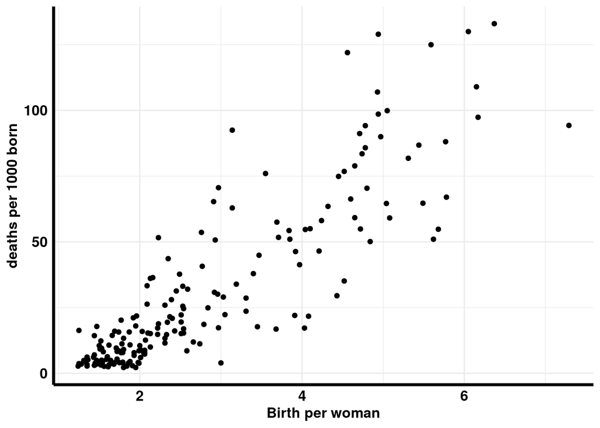

```r
data_2015 %>%
  ggplot(aes(x = birth, y = death_per_1000)) +
  geom_point() +
  labs(x = "Birth per woman",
       y = "deaths per 1000 born") +
    theme_minimal() +
   theme(axis.line = element_line(size = 1.2),
        text = element_text(size = 12, color = "black", face = "bold"),
        axis.text = element_text(size = 12, color = "black", face = "bold")
        )
```

Is there a correlation between births per woman and child mortality? Do a correlation test.

```r
cor.test(data_2015$birth, data_2015$death_per_1000)
```

```
##
##  Pearson's product-moment correlation
##
## data:  data_2015$birth and data_2015$death_per_1000
## t = 23.961, df = 182, p-value < 2.2e-16
## alternative hypothesis: true correlation is not equal to 0
## 95 percent confidence interval:
##  0.8315416 0.9023036
## sample estimates:
##       cor
## 0.8713825
```

What does the correlation coefficient tell you? There is a strong positive correlation between birth per woman and deaths per 1000 child in the year 2015

Between income vs mortality in 1945 and birth vs mortality in 2015, which has a stronger correlation?

```r
data_1945 <- mortality_and_income_and_birth %>%
  filter(year == 1945)
```

```r
cor.test(data_1945$log10_income, data_1945$death_per_1000)
```

```
##
##  Pearson's product-moment correlation
##
## data:  data_1945$log10_income and data_1945$death_per_1000
## t = -10.58, df = 182, p-value < 2.2e-16
## alternative hypothesis: true correlation is not equal to 0
## 95 percent confidence interval:
##  -0.6993335 -0.5187507
## sample estimates:
##        cor
## -0.6171025
```

The magnitude (absolute value) of birth vs. death at 2015 is greater than that of income vs. death at 1945. Thus a stronger correlation for birth vs. death at 2015.

# Exercise two

Now let’s practice linear regression. We’ll use the Puromycin data again. However, we will use the drug treated data this time. Again, we are looking at the rate of an enzyme across substrate concentrations, but this time the enzyme is treated with the drug puromycin.

```r
Puromycin_treat <- Puromycin %>%
  filter(state == "treated") %>%
  mutate(one_over_v = 1/rate) %>%
  mutate(one_over_s = 1/conc)

head(Puromycin_treat)
```

```
##   conc rate   state  one_over_v one_over_s
## 1 0.02   76 treated 0.013157895  50.000000
## 2 0.02   47 treated 0.021276596  50.000000
## 3 0.06   97 treated 0.010309278  16.666667
## 4 0.06  107 treated 0.009345794  16.666667
## 5 0.11  123 treated 0.008130081   9.090909
## 6 0.11  139 treated 0.007194245   9.090909
```

## Set up the model and interpret the model

```r
model_puro <- lm(one_over_v ~  one_over_s, data = Puromycin_treat)
summary(model_puro)
```

```
##
## Call:
## lm(formula = one_over_v ~ one_over_s, data = Puromycin_treat)
##
## Residuals:
##        Min         1Q     Median         3Q        Max
## -0.0043103 -0.0003742 -0.0000510  0.0004549  0.0038084
##
## Coefficients:
##              Estimate Std. Error t value Pr(>|t|)
## (Intercept) 0.0051072  0.0007040   7.255 2.74e-05 ***
## one_over_s  0.0002472  0.0000321   7.700 1.64e-05 ***
## ---
## Signif. codes:  0 '***' 0.001 '**' 0.01 '*' 0.05 '.' 0.1 ' ' 1
##
## Residual standard error: 0.001892 on 10 degrees of freedom
## Multiple R-squared:  0.8557, Adjusted R-squared:  0.8413
## F-statistic:  59.3 on 1 and 10 DF,  p-value: 1.642e-05
```

What is the intercept and slope? The intersept is 0.0051 and slope is 0.000247

1/v = 0.0051 + 0.000247*1/s

What is the R^2 and what does it mean? R^2 is 0.84, which means 84% of the variances in the data is explained by the model

Calculate K and Vmax from the coefficients.

```r
1/0.0051    #Vmax
```

```
## [1] 196.0784
```

```r
0.000247/0.0051 #K
```

```
## [1] 0.04843137
```

How does puromycin affect the K and Vmax of this enzyme?

The parameters for the ctrl were: Vmax = 143, and K = 0.03  
So puromycin increased both Vmax and K.

## Visualize the model under the double reciprocal scale and the original scale

Make your plots here:

```r
fitted_rate_puro <- data.frame(
  "one_over_s" = seq(min(Puromycin_treat$one_over_s), max(Puromycin_treat$one_over_s), by = 0.1)
) %>%
  mutate(one_over_v = 0.000247*(one_over_s) + 0.0051) %>%
  mutate(conc = 1/one_over_s) %>%
  mutate(rate = 1/one_over_v)
```

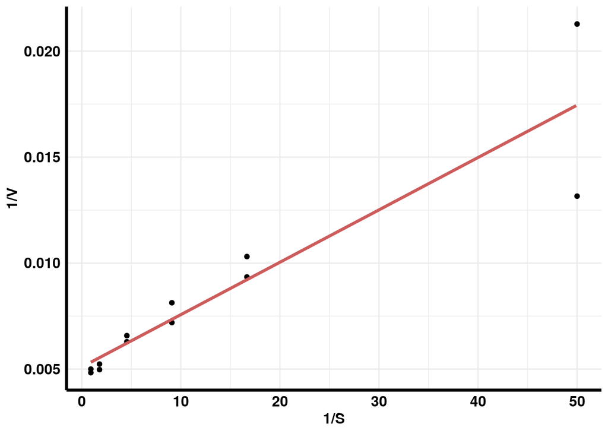

```r
Puromycin_treat %>%
  ggplot(aes(x = one_over_s, y = one_over_v)) +
  geom_point() +
  geom_line(data = fitted_rate_puro, size = 1.2, color = "indianred") +
  labs(x = "1/S",
       y = "1/V") +
  theme_minimal() +
  theme(axis.line = element_line(size = 1.2),
        text = element_text(size = 12, color = "black", face = "bold"),
        axis.text = element_text(size = 12, color = "black", face = "bold")
        )
```

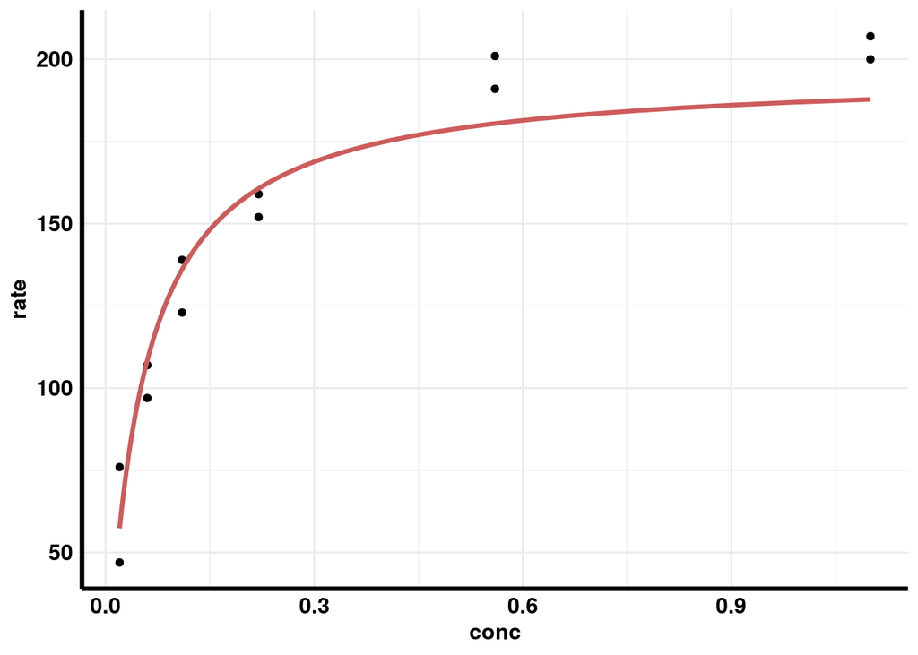

```r
Puromycin_treat %>%
  ggplot(aes(x = conc, y = rate)) +
  geom_point() +
  geom_line(data = fitted_rate_puro, size = 1.2, color = "indianred") +
  theme_minimal() +
   theme(axis.line = element_line(size = 1.2),
        text = element_text(size = 12, color = "black", face = "bold"),
        axis.text = element_text(size = 12, color = "black", face = "bold")
        )
```